# Metagenomic Human Mitogenomes

# Libraries and data

```r
library(dplyr)
library(readr)
library(ggplot2)
library(tidyr)
library(ggthemes)
library(maps)
library(ggrepel)
```

The final outputs from the snakemake workflow are as follows: 1) `summary/all_samples_rCRS_stats.tsv`: Statistics on the contigs with BLASTn hits. 2) `summary/all_samples_rCRS_hg.tsv`: Haplogroups assignment for each sample. 3) `summary/all__rCRS_fasta.depth`: Combined depth of coverage of all samples against the human mtDNA rCRS.

```r
fasta_stats = read_tsv("summary/all_samples_rCRS_stats.tsv", show_col_types = F) %>%
  separate(file, into= c("folder", "study", "sample"), sep = "/") %>%
  separate(sample, into = c("sample", "ext"), sep = "_rCRS") %>%
  select(study, sample, num_seqs, sum_len, min_len, max_len, `GC(%)`)


haplogrep_colnames = c("SampleID", "Haplogroup", "Rank", "Quality", "Range")
haplogrep_stats = read_tsv("summary/all_samples_rCRS_hg.tsv",show_col_types = F,
                           col_names = haplogrep_colnames) %>%
  separate(SampleID, into= c("folder", "study", "sample"), sep = "/") %>%
  separate(sample, into = c("sample", "ext"), sep = "_rCRS") %>%
  select(study, sample, Haplogroup, Quality, Range)

all_rCRS_depth = read_tsv("summary/all__rCRS_fasta.depth", show_col_types = F,
                          col_names = c("chr", "pos", "number_of_samples"))
```

Additionally, we need load the sample metadata `sample_metadata.tsv` and the genome annotation of the mitochondrial reference genome (rCRS) `reference/rCRS.gff3`.

```r
sample_metadata = read_tsv("sample_metadata.tsv",show_col_types = F)

rCRS_gff <- read_tsv("reference/rCRS.gff3", col_names = FALSE, show_col_types = F) %>%
  select(start = X3, end = X4, gene = X9)
```

# Figure 1

## Figure 1a

**World map annotated with mtDNA positive and negative countries**

```r
# Total number of samples
number_of_sample = nrow(sample_metadata)

# Number of countries
number_of_countries = sample_metadata %>%
  group_by(country) %>%
  summarise(count = n()) %>%
  na.omit() %>%
  nrow()

# Number of studies
number_of_studies = sample_metadata %>%
  group_by(study) %>%
  summarise(count = n()) %>%
  na.omit() %>%
  nrow()

# Number of mtDNA positive/negative samples
mt_counts = left_join(sample_metadata,
                      fasta_stats, by = c("study", "sample")) %>%
  mutate(num_seqs = ifelse(is.na(num_seqs), 0, num_seqs)) %>%
  summarise(mt_positive = sum(num_seqs > 0),
            mt_negative = sum(num_seqs == 0))


# Number of studies with mtDNA
number_of_mt_positive_studies = left_join(sample_metadata,
                                          fasta_stats,
                                          by = c("study", "sample")) %>%
  filter(num_seqs > 0) %>%
  group_by(study) %>%
  summarise(count = n()) %>%
  na.omit() %>%
  nrow()


cat("The total number of sample: ", number_of_sample, "\n")
```

```
## The total number of sample:  9428
```

```r
cat("The number of datasets: ", number_of_studies, "\n")
```

```
## The number of datasets:  47
```

```r
cat("The number of countries: ", number_of_countries, "\n")
```

```
## The number of countries:  31
```

```r
cat("The number of mtDNA positive samples: ", mt_counts$mt_positive, "\n")
```

```
## The number of mtDNA positive samples:  1817
```

```r
cat("The number of mtDNA negative samples: ", mt_counts$mt_negative, "\n")
```

```
## The number of mtDNA negative samples:  7611
```

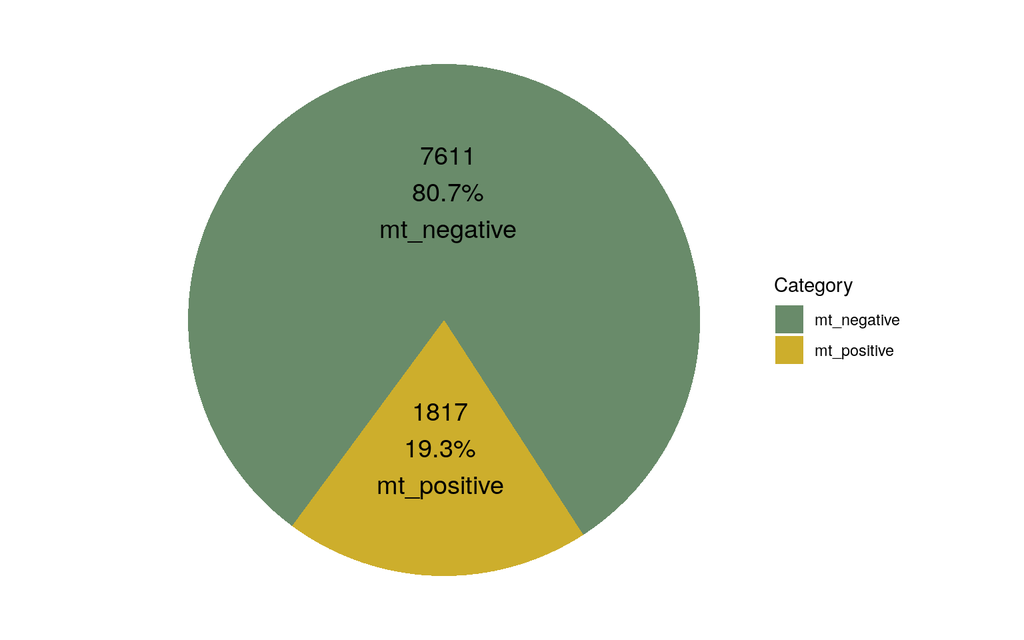

```r
mt_counts_long <- mt_counts %>%
  pivot_longer(cols = everything(), names_to = "category", values_to = "count") %>%
  mutate(percentage = count / sum(count) * 100,
         label = paste0(count, "\n", sprintf("%.1f%%", percentage), "\n", category))


ggplot(mt_counts_long, aes(x = "", y = count, fill = category)) +
  geom_bar(stat = "identity", width = 1) +
  coord_polar(theta = "y", start = 700, direction = 1) +
  theme_void() +
  scale_fill_manual(values = c("mt_positive" = "#CDAE2C", "mt_negative" = "#698B6A")) +
  labs(fill = "Category")+
  geom_text(aes(label = label, y = cumsum(count) - count / 2), size = 5, color = "black")
```

Annotated world map

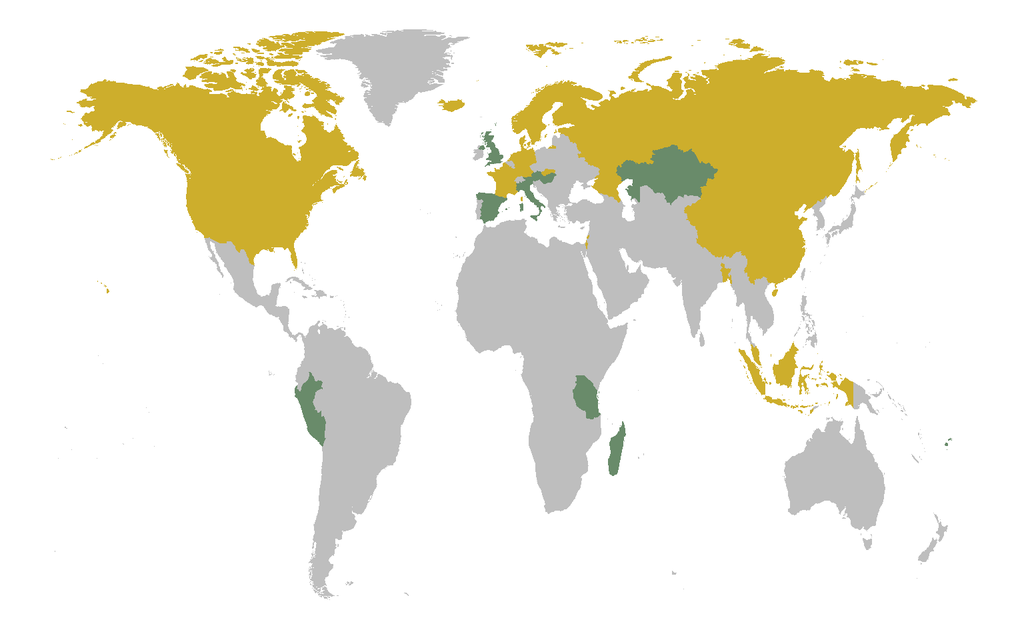

```r
world_coordinates <- map_data("world")

positive_countries = left_join(sample_metadata, fasta_stats,
                               by = c("study", "sample")) %>%
  filter(num_seqs > 0) %>%
  select(country) %>%
  unique()%>% na.omit() %>% pull(country)

negative_countries = left_join(sample_metadata, fasta_stats,
                               by = c("study", "sample")) %>%
  filter(!country %in% positive_countries) %>%
  select(country) %>%
  unique()%>% na.omit()%>% pull()


positive_map = subset(world_coordinates, region %in% positive_countries)
total_map = subset(world_coordinates, region %in% c(negative_countries, positive_countries))
other_map = subset(world_coordinates, !region %in% c(negative_countries, positive_countries, "Antarctica"))



ggplot() +
  geom_map(data = other_map, map = other_map, aes(long, lat, map_id = region), fill = "gray", alpha=1) +
  geom_map(data = total_map, map = total_map, aes(long, lat, map_id = region), fill = "#698B6A", alpha=1) +
  geom_map(data = positive_map, map = positive_map, aes(long, lat, map_id = region), fill = "#CDAE2C", alpha=1) +
  scale_color_identity() +
  theme_void()
```

## Figure 1b

**Bar chart showing the log-scale total number of mtDNA positive samples and the total number of samples per countries.** Note: Only countries with > 5 samples are shown in the plot.

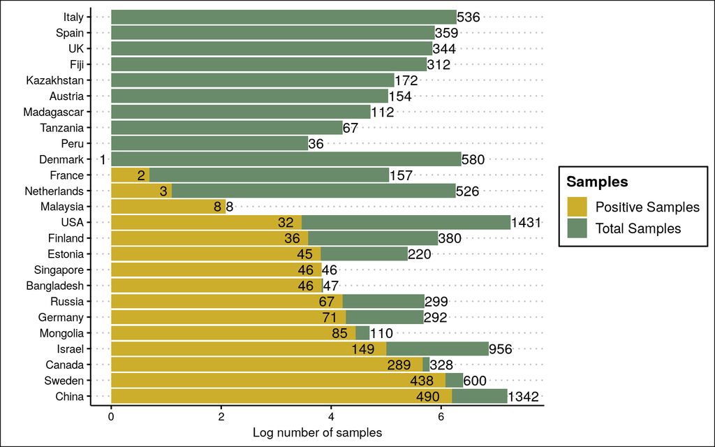

```r
country_ratio_df = left_join(sample_metadata, fasta_stats, by = c("study", "sample")) %>%
  group_by(country) %>%
  summarise(positive_countries = sum(num_seqs > 0, na.rm = TRUE),
            total_samples = n()) %>%
  mutate(positive_ratio = positive_countries / total_samples) %>%
  na.omit()%>%
  filter(total_samples > 5)

# countries with less than 5 samples are not shown in the plot

country_order = country_ratio_df %>%
  arrange(desc(positive_countries), positive_ratio, total_samples) %>%
  pull(country)


ggplot(country_ratio_df, aes(y = country)) +
  scale_y_discrete(limits=country_order)+
  geom_bar(aes(x = log(total_samples), fill = "Total Samples"), stat = "identity", alpha = 1) +
  geom_bar(aes(x = log(positive_countries), fill = "Positive Samples"),
           stat = "identity", position = position_stack(reverse = T), alpha = 1) +
  geom_text(data = subset(country_ratio_df, total_samples > 0),
            aes(x = log(total_samples), label = total_samples),
            hjust = 0, size = 4, color = "black") +
  geom_text(data = subset(country_ratio_df, positive_countries > 0),
            aes(x = log(positive_countries), label = positive_countries),
            hjust = 1.5, size = 4, color = "black") +
  scale_fill_manual(name = "Samples", values = c("Total Samples" = "#698B6A", "Positive Samples" = "#CDAE2C")) +
  labs(y = "", x = "Log number of samples") +
  scale_x_continuous(limits = c(0,7.5))+
  theme_clean()
```

## Figure 1c

**Stacked bar plot with the number of samples per each sample type**

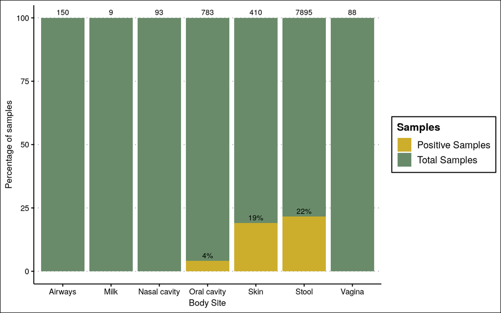

```r
body_site_count = left_join(sample_metadata, fasta_stats, by = c("study", "sample")) %>%
  group_by(body_site) %>%
  summarise(positive_samples = sum(num_seqs > 0, na.rm = TRUE),
            total_samples = n()) %>%
  mutate(positive_ratio = positive_samples * 100 / total_samples)


ggplot(body_site_count, aes(x = body_site)) +
  geom_bar(aes(y = 100, fill = "Total Samples"), stat = "identity", alpha = 1) +
  geom_bar(aes(y = positive_ratio, fill = "Positive Samples"), stat = "identity", position = "identity", alpha = 1) +
  geom_text(data = subset(body_site_count, total_samples > 0),
            aes(y = 100, label = total_samples),
            vjust = -0.5, size = 3, color = "black") +
  geom_text(data = subset(body_site_count, positive_samples > 0),
            aes(y = positive_ratio, label = paste0(round(positive_ratio), "%")),
            vjust = -0.5, size = 3, color = "black") +
  scale_fill_manual(name = "Samples", values = c("Total Samples" = "#698B6A", "Positive Samples" =  "#CDAE2C")) +
  labs(x = "Body Site", y = "Percentage of samples") +
  theme_clean()
```

## Figure 1d

**Histogram showing the distribution of the total lengths of contigs of each sample with > 90% similarity and > 500 bitscore based on BLASTn search against the rCRS**

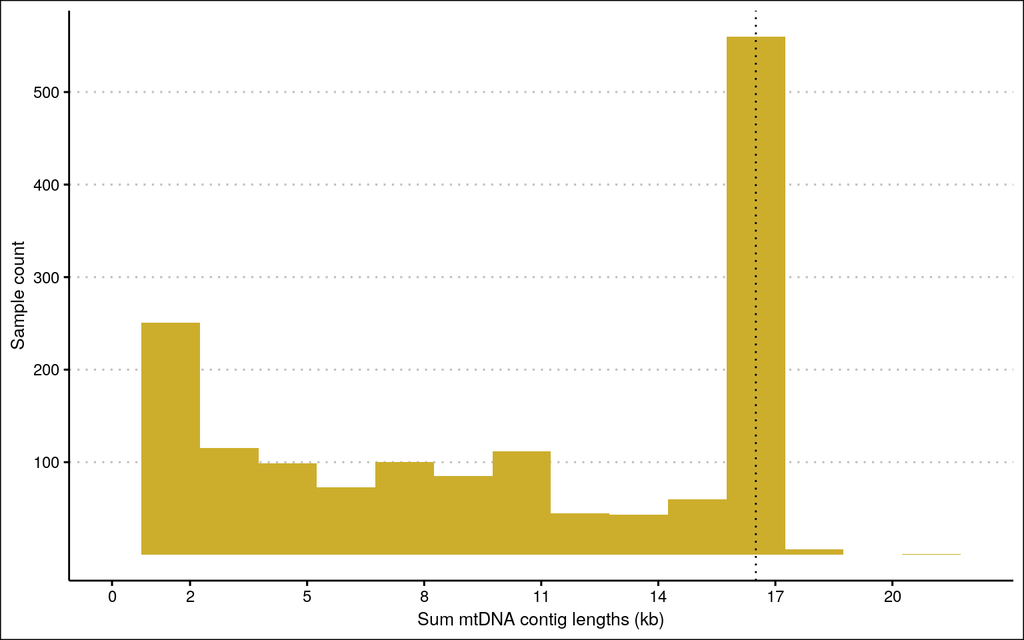

```r
fasta_stats %>% filter(num_seqs > 0)%>%
  ggplot(., aes(x = sum_len/1000)) +
  geom_histogram(fill = "#CDAE2C", alpha = 1, binwidth = 1.5) +
  scale_x_continuous(limits = c(0,22), breaks = c(0, 2, 5, 8, 11, 14, 17, 20))+
  scale_y_continuous(breaks = c(100, 200, 300, 400, 500, 600))+
  geom_vline(xintercept = 16.5,  linetype="dotted")+
  labs(y = "Sample count", x = "Sum mtDNA contig lengths (kb)")+
  theme_clean()
```

## Figure 1e

**Genetic map of the human mitochondrial genome, displaying genes and the number of samples covering each position.**

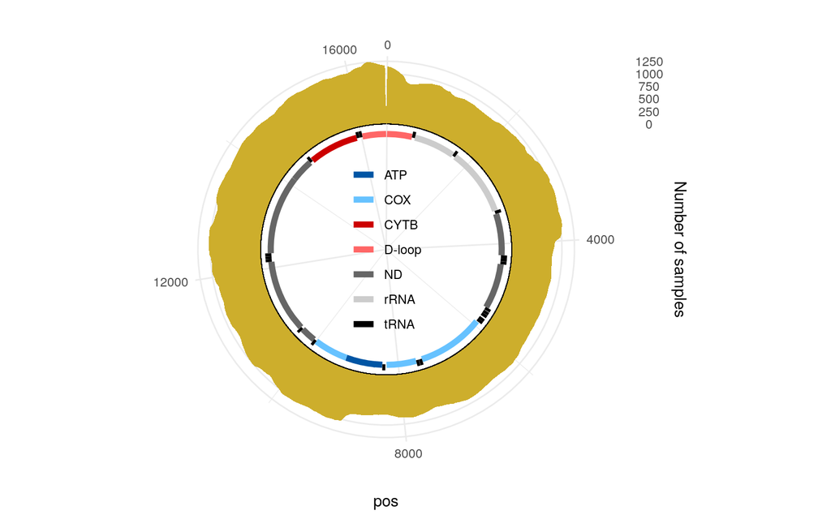

```r
all_rCRS_depth %>%
  mutate(pos = (pos - 1) %/% 50 * 50 ) %>%
  group_by(chr, pos) %>%
  summarise(number_of_samples = mean(number_of_samples, na.rm = TRUE), .groups = "drop") %>%
  ggplot(., aes(x = pos, y = number_of_samples))+
  geom_area(fill = "#CDAE2C", alpha = 1)+
  theme_minimal()+
  coord_radial(expand = F)+
  scale_y_continuous(limits = c(-2500, 1350), breaks = c(0, 250, 500, 750, 1000, 1250),
                     position = "right", expand = c(0, 0))+
  geom_segment(x = 0, xend = 16570, y = 0, yend = 0 , color = "black", size = 0.2)+
  geom_segment(data = rCRS_gff, aes(x = start, xend = end, y = ifelse(gene == "tRNA", -150, -200),
                                    yend = ifelse(gene == "tRNA", -150, -200), color = gene), size = 2)+
  scale_color_manual(values = c("#0055A4", "#66C2FF", "#CC0000", "#FF6666", "#666666", "#CCCCCC", "#000000"))+
  theme(legend.position = c(0.5, 0.5), legend.title = element_blank())+
  labs(y = "Number of samples")
```

## Figure 1f

**Pie-chart with the frequency of the mtDNA haplogroups detected in all studies. Only samples with > 5000 nt mtDNA positions covered and haplogroup assignment quality > 0.9 are considered.**

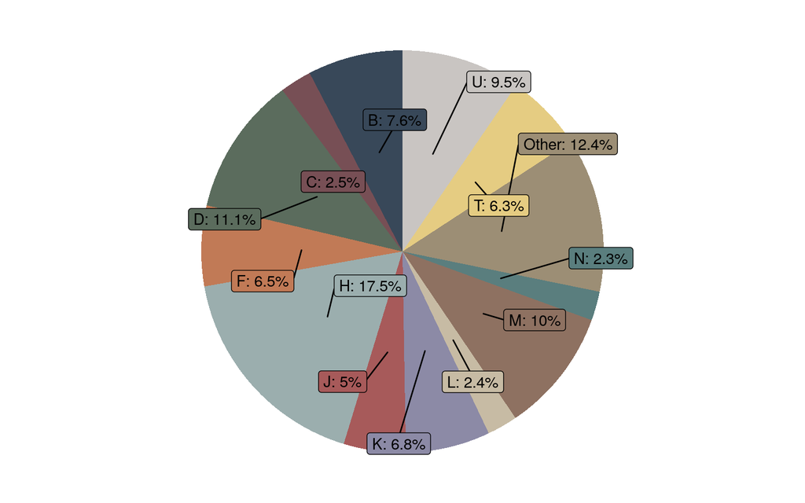

```r
new_colors <- c("#384859", "#774F55", "#5B6C5D", "#C17A56", "#9BAEAE",
                "#A75A5A", "#8C8AA6", "#C7BBA4", "#8E7161", "#5A7E7E",
                "#9C8E75", "#E5CC82", "#C9C5C2", "#D4AF37", "#E3D9C6")


haplogrep_stats %>%
  left_join(., fasta_stats, by = c("study", "sample")) %>%
  mutate(major_haplo = substr(Haplogroup,1,1)) %>%
  filter(Quality > 0.9 & sum_len > 5000) %>%
  group_by(major_haplo) %>%
  summarise(count = n()) %>%
  mutate(percentage = (count / sum(count)) * 100) %>%
  mutate(major_haplo_most = if_else(percentage < 2, "Other",
                               as.character(major_haplo))) %>%
  group_by(major_haplo_most) %>%
  summarise(count = sum(count), percentage = sum(percentage)) %>%
  ggplot(., aes(x = "", y = percentage, fill = major_haplo_most)) +
  geom_bar(stat = "identity", width = 1) +
  coord_polar("y", start = 0) +
  theme_void() +
  theme(legend.position = "bottom") +
  scale_fill_manual(values = new_colors) +
  theme(legend.position = "none")+
  geom_label_repel(aes(label = paste(major_haplo_most, ": ", round(percentage, 1), "%", sep = "")),
                 position = position_stack(vjust = 0.5),
                 box.padding = 1,
                 force_pull = 1,
                 segment.color = "black")
```